# Introduction to cellcount - Draft vignette

### Test data results for *Shewanella* IRI-160

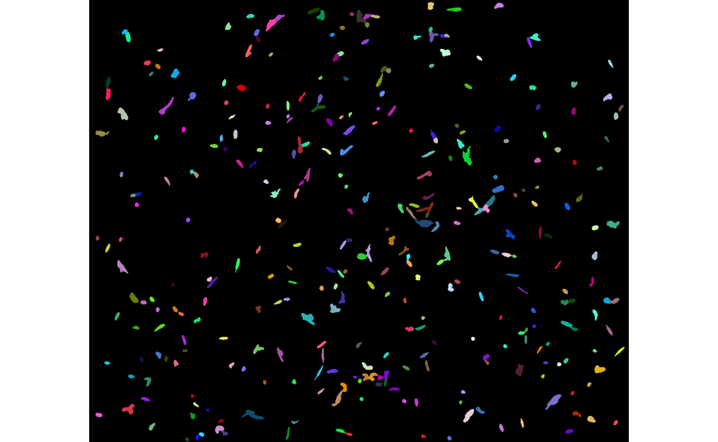

```
              Image_File_Name     Cell_Count within_outlier_range
1  img_Shewanella_Demo_01.tif            288                 TRUE
2  img_Shewanella_Demo_02.tif            282                 TRUE
3  img_Shewanella_Demo_03.tif            259                 TRUE
4  img_Shewanella_Demo_04.tif            317                 TRUE
5  img_Shewanella_Demo_05.tif            330                 TRUE
6  img_Shewanella_Demo_06.tif            291                 TRUE
7  img_Shewanella_Demo_07.tif            268                 TRUE
8  img_Shewanella_Demo_08.tif            293                 TRUE
9  img_Shewanella_Demo_09.tif            273                 TRUE
10 img_Shewanella_Demo_10.tif            290                 TRUE
11                 Cell Total           2891
12               Cell Density 14716566666.67
13            Imaging Average          289.1
14   Total Volume Cell per mL  7358283333.34
```

# Shiny app user-interface for *cellcount* analysis:

Informal discussions with researchers have expressed interest in an easy-to-use analysis interface for inexperienced R users to utilize the *cellcount* package. The following overview uses ‘Shiny’ apps to enter input data and process images. This results in the use of two functions, *input_data_GUI* and *analyze images_GUI*, to run the entire analysis process as outlined previously, and in the **cellcount_sandbox.R** script under the *cellcount_files_HABF* folder. Several packages are required to utilize these UI tools:

- *shiny* (Chang et al. 2022)
- *shinyalert* (Attali, Edwards, and Wang 2021)
- *shinyFiles* (Pedersen et al. 2022)
- *shinyjs* (Attali 2021)
- *DT* (Xie et al. 2023)
- *shinyBS* (Bailey 2022)

The following code can be used to bring packages into the R environment once the packages have been installed using CRAN:

```r
library(shiny)
library(shinyalert)
library(shinyFiles)
library(shinyjs)
library(DT)
library(shinyBS)
```

### Inputting data

The *input_data_GUI* function generates a Shiny UI where users can enter information regarding directories, numerical and categorical data, and selecting analysis type. Tabs to the left of the UI separate particular categories for easy organization and contain interactive buttons or drop-down menus to enter and select appropriate data. Some buttons change from red to green to provide an organized data entry approach. Once all data has been provided, users complete the input of data by selecting the “Completion” tab and clicking the “Submit data entries” button to export data to the local R environment.

[figure not shown]

Visual demonstration of the Shiny GUI for inputting data.

### Running the image analysis

*analyze_images_GUI* is a simple UI that contains three interactive buttons as well as an interactive data table. “Run Image Analysis” simply runs the image analysis previously outlined in this document and uses the inputted data from the *input_data_GUI* function. Once the completion sound has been played (using the *beepr* package), users can click the “Refresh” button to update the table below with the analyzed data and review. Once finished with analysis, the “Close window” button to exit the UI.

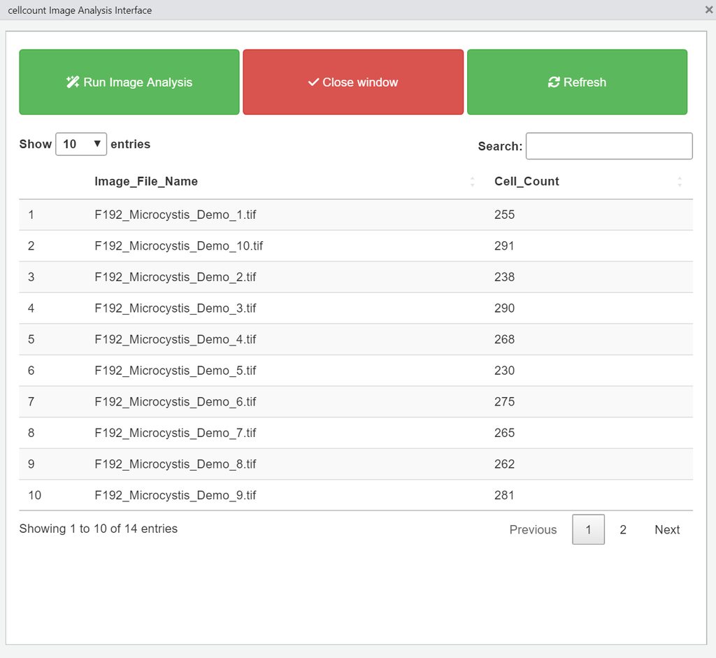

Visual demonstration of the Shiny GUI for running image analysis.

# Package limitations/constraints:

The current version of this package may be limiting for some users regarding processing power. Analysis with this package uses local memory, which may be limiting if expected to analyze large amounts of images in batches. It is recommended to have at least 16GB of localized RAM, the ability to use cloud computing (i.e. Microsoft Azure), or organize images in easier-to-analyze batches to reduce local memory strain.

Cells with a uniform chloroplast (auto-fluorescence) or fluorescent dyes illuminating the entire cell are the most useful when using this version of *cellcount* for enumeration purposes. Other cells such as dinoflagellates (i.e. *Karenia* sp.) that contain multiple discriminate chloroplasts are difficult to enumerate as the *cellcount* approach may separate these lobed chloroplasts into unique cells, causing enumeration outputs to be unreliable. *In-situ* hybridization dyes that target specific species or genera may be helpful if other cellular features are not acceptable in providing accurate enumeration.

Users must be aware that this package does not contain abilities to classify distinct cell types (i.e., species). The development of this package utilized mono-culture of various cyanobacteria species. Users may find difficulty in using this analysis tool if cultures contain heavy amounts of particulates, other cellular debris, and contamination of other species. It is advised to use this tool for single-species only, however future developments of this tool are planned to include identifying cell features and deep-learning mechanics that use image libraries of unique cellular species.

Outside of package limitations, users must be aware of limitations that may arise from poor microscope image quality; reduce room lighting for best results, avoid heavy background fluorescence, reduce debris/particulates, and so forth. Good images produce good *cellcount* results.

# Conclusions:

*cellcount* provides an open-source approach to bacteria and cyanobacteria enumeration that is accurate and rapid compared to standardized microscopy methods. The open-source approach allows researchers to access this tool for free and to modify and make additions to the existing code to fulfill particular needs, whereas the Shiny GUI allows users of all coding backgrounds to utilize this analysis tool.

# Literature Cited

Attali, D. 2021. “Shinyjs: Easily Improve the User Experience of Your Shiny Apps in Seconds.” https://cran.r-project.org/web/packages/shinyjs/index.html.

Attali, D., T. Edwards, and Z. Wang. 2021. “Shinyalert: Easily Create Pretty Popup Messages (Modals) in Shiny.” https://cran.r-project.org/web/packages/shinyalert/index.html.

Baath, R., and A. Dobbyn. 2018. “Beepr: Easily Play Notification Sounds on Any Platform.” https://cran.r-project.org/web/packages/beepr/index.html.

Bailey, E. 2022. “shinyBS: Twitter Bootstrap Components for Shiny.” https://cran.r-project.org/web/packages/shinyBS/index.html.

Bivand, R., F. Leisch, and Martin Maechler. 2021. “Bitmap Images/Pixel Maps, R Package Version 0.4.12.” https://cran.r-project.org/package=pixmap.

Chang, W., J. Cheng, J. Allaire, M. Boutros, and W. Huber. 2022. “Shiny: Web Application Framework for R.” https://cran.r-project.org/web/packages/shiny/index.html.

Hijmans, R.J, J. van Etten, M. Sumner, J. Cheng, D. Baston, A. Bevan, R. Bivand, et al. 2023. “Raster: Geographic Data Analysis and Modeling.” https://cran.r-project.org/web/packages/raster/index.html.

Pau, G., F. Fuchs, O. Skylar, M. Boutros, and W. Huber. 2010. “EBImage—an R Package for Image Processing with Applications to Cellular Phenotypes.” *Bioinformatics* 26 (7): 979–81. https://doi.org/10.1093/bioinformatics/btq046.

Pedersen, T.L., V. Nijs, T. Schaffner, and E. Nantz. 2022. “shinyFiles: A Server-Side File System Viewer for Shiny.” https://cran.r-project.org/web/packages/shinyFiles/index.html.

Pokrzywinski, K., B.M. Boyd, and S.J. Smith. 2019. “A High-Throughput Method for Counting Cyanobacteria Using Fluorescence Microscopy.” https://doi.org/10.21079/11681/33870.

Urbanek, S., and K. Johnson. 2022. “Tiff: Read and Write TIFF Images. R Package Version 0.1-11.” https://www.rforge.net/tiff/.

Wetzel, R.G., and G.E. Likens. 2000. *Limnological Analyses - 3rd Edition*. https://doi.org/10.1007/978-1-4757-3250-4.

Xie, Y., J. Cheng, X. Tan, J.J. Allaire, M. Girlich, G.F. Ellis, J. Rauh, et al. 2023. “DT: A Wrapper of the JavaScript Library DataTables.” https://cran.r-project.org/web/packages/DT/index.html.